# Ames house prices

NAME: Federico Melograna

BADGE: 789256

NICKNAME: f.melograna

TEAM: Pifferai_Magici

ROUND: 1st

### Summary

My strategy was:

1. Caricare le Librerie
2. Imputare i missing value non random con 0
3. imputare i missing value con la moda
4. Esplorazione delle variabili
5. Creazione ed eliminazione di variabili
6. Modellazione tramite XGB, SVM, Lasso
7. Media pesata delle tre previsioni

### References:

- https://www.kaggle.com/erikbruin/house-prices-lasso-xgboost-and-a-detailed-eda
- http://topepo.github.io/caret/index.html

### Models

- LM GLM MICE Lasso XGB SVM

### Non-standard R packages

- VIM plyr dplyr XGBoost mice caret xgboost car ggplot2
- VIM imputation and visualization of missing values
- plyr,dplyr strumenti utili per maneggiare dati eg. (%>%)
- XGBoost, serve per performare un gradient boosting eg. method=xgb
- mice: serve per fare una imputazione multipla condizionata alle altre variabili
- caret: Classification and regression, pacchetto che incorpora molteplici modelli al suo interno con una struttura standard
- car: companion to applied regression, usato per operazioni accessorie e grafiche eg. scatterplot
- ggplot2: metodo per disegnare grafici più accurati e diversificati eg. ggplot
- ggrepel: Provides text and label geoms for ’ggplot2, serve per mettere etichette che non si sovrappongano ai dati

### R code to reproduce the last submission:

```r
# get the required R packages
library(VIM)
library(knitr)
library(ggplot2)
library(plyr)
library(dplyr)
library(corrplot)
library(caret)
library(gridExtra)
library(scales)
library(Rmisc)
library(ggrepel)
library(randomForest)
library(psych)
library(xgboost)
library(car)
# import data
train <- read.csv("http://bee-fore.s3-eu-west-1.amazonaws.com/datasets/60.csv")
test <- read.csv("http://bee-fore.s3-eu-west-1.amazonaws.com/datasets/61.csv")

test$SalePrice=NA
dati2=rbind(train,test);da=dati2
da$SalePrice=log(da$SalePrice)
all=dati2
all$SalePrice=da$SalePrice
##
sp=all$SalePrice

#LOG
all_nm=all
dati2=all#dataset non modificato come benchmark

##MISSING IN POOL
levels(dati2$Pool.QC)
```

```
[1] "Ex" "Gd" "TA" "Fa"
```

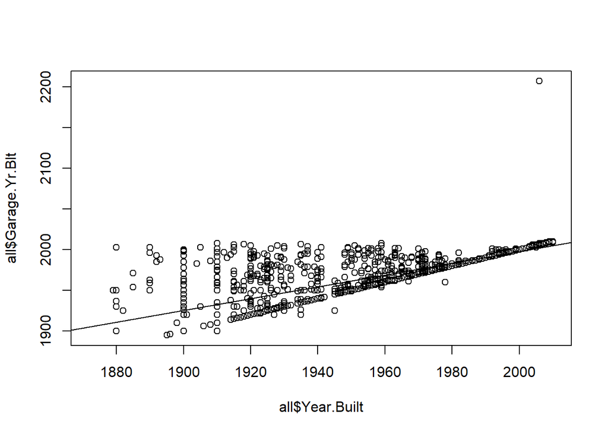

```r
all$Pool.QC=as.character(all$Pool.QC)
all$Pool.QC[is.na(all$Pool.QC)] <- 'None'
Qualities <- c('None' = 0,  'Fa' = 2, 'TA' = 3, 'Gd' = 4, 'Ex' = 5)
all$Pool.QC<-as.integer(revalue(all$Pool.QC, Qualities))

###MISSING IN MISC FEATURE
##imputiamo adesso i missing in misc feature
all$Misc.Feature=as.character(all$Misc.Feature)
all$Misc.Feature[is.na(all$Misc.Feature)] <- 'None'
all$Misc.Feature <- as.factor(all$Misc.Feature)

#######################
#IMPUTARE MISSING IN ALLEY

all$Alley=as.character(all$Alley)
all$Alley[is.na(all$Alley)] <- 'None'
all$Alley <- as.factor(all$Alley)
##MISSING IN FENCE
all$Fence=as.character(all$Fence)
all$Fence[is.na(all$Fence)] <- 'None'
all$Fence <- as.factor(all$Fence)
##MISSING IN FIREPLACE
Qualities <- c('None' = 0, 'Po' = 1, 'Fa' = 2, 'TA' = 3, 'Gd' = 4, 'Ex' = 5)
all$Fireplace.Qu=as.character(all$Fireplace.Qu)
all$Fireplace.Qu[is.na(all$Fireplace.Qu)] <- 'None'
all$Fireplace.Qu<-as.integer(revalue(all$Fireplace.Qu, Qualities))
all$Fireplace.Qu=as.factor(all$Fireplace.Qu)
###MISSING IN LOT.FRONTAGE
###Lot.Frontage
for (i in 1:nrow(all)){
  if(is.na(all$Lot.Frontage[i])){
    all$Lot.Frontage[i] <- as.integer(median(all$Lot.Frontage[all$Neighborhood==all$Neighborhood[i]], na.rm=TRUE))
  }
}
########MISSING IN LOT.SHAPE
all$Lot.Shape<-as.integer(revalue(all$Lot.Shape, c('IR3'=0, 'IR2'=1, 'IR1'=2, 'Reg'=3)))
###MISSING GARAGE
##adesso garage
##per rimpiazzare anno mancante garage, modello con anno casa

mod_g=lm(all$Garage.Yr.Blt~all$Year.Built)
plot(all$Garage.Yr.Blt~all$Year.Built)
abline(mod_g)
```

```r
garagey=all$Garage.Yr.Blt
yeay=all$Year.Built[is.na(all$Garage.Yr.Blt)]
garagey[is.na(garagey)]=round(mod_g$coefficients[1]+mod_g$coefficients[2]*yeay)
###adesso rimettiamo dentro
all$Garage.Yr.Blt=garagey
####
all$Garage.Type=as.character(all$Garage.Type)
all$Garage.Type[all$Garage.Area==0]="none"
all$Garage.Type=as.factor(all$Garage.Type)
##risolto su garage type
all$Garage.Finish=as.character(all$Garage.Finish)
all$Garage.Finish[all$Garage.Area==0]="none"
all$Garage.Finish=as.factor(all$Garage.Finish)
temp=all[all$Garage.Cars==1,]
##la moda è unf
all$Garage.Finish[2128]="Unf"
##imputato il primo, nel secondo i2561
temp2=all[all$Garage.Type=="Detchd",]
all$Garage.Finish[2561]="Unf"
all$Garage.Cars[2561]=2
all$Garage.Area[2561]=420
all$Garage.Qual[2561]="TA"
all$Garage.Cond[2561]="TA"
#QUAL
all$Garage.Qual=as.character(all$Garage.Qual)
all$Garage.Qual[all$Garage.Area==0]="none"
all$Garage.Qual=as.factor(all$Garage.Qual)
all$Garage.Qual[2128]="TA"

###GARAGE:COND
all$Garage.Cond=as.character(all$Garage.Cond)
all$Garage.Cond[all$Garage.Area==0]="none"
all$Garage.Cond=as.factor(all$Garage.Cond)
all$Garage.Cond[2128]="TA"
######

###garage finito

all$Garage.Yr.Blt[all$Garage.Yr.Blt>2018]=2007

###
#BASEMENT VARIABLES
####

all$Bsmt.Cond=as.character(all$Bsmt.Cond)

all$Bsmt.Cond[all$Bsmt.Full.Bath==0 & is.na(all$Bsmt.Cond)]="none"

all$Bsmt.Cond=as.factor(all$Bsmt.Cond)

####Exposure
all$Bsmt.Full.Bath[is.na(all$Bsmt.Exposure)]
```

```
 [1]  0  0  0  0  0  0  0  0  0  0  0  0  0  0  0  0  0  0  0  0  0 NA  0  0  0  0  0  0  0  0  0  0  0  0  0  0  0  0  0  0  0  0  0  0  0  0  0  0  0  0  0  0  0  0  0  0  0  0  0  0  0  0  0  0  0  0  0  0  0  0  0  0
[73]  0  0  0  0  0  0  0
```

```r
table(all$Bsmt.Exposure)
```

```
       Av   Gd   Mn   No
   4  418  284  239 1906
```

```r
all$Bsmt.Exposure=as.character(all$Bsmt.Exposure)
str(all$Bsmt.Full.Bath)
```

```
 int [1:2930] 0 0 0 0 1 0 1 0 1 1 ...
```

```r
all$Bsmt.Exposure[all$Bsmt.Full.Bath==0 & is.na(all$Bsmt.Exposure)]="none"
table(all$Bsmt.Exposure)
```

```
       Av   Gd   Mn   No none
   4  418  284  239 1906   78
```

```r
all$Bsmt.Exposure=as.factor(all$Bsmt.Exposure)

###BSmt.Qual

all$Bsmt.Full.Bath[is.na(all$Bsmt.Qual)]
```

```
 [1]  0  0  0  0  0  0  0  0  0  0  0  0  0  0  0  0  0  0  0  0  0 NA  0  0  0  0  0  0  0  0  0  0  0  0  0  0  0  0  0  0  0  0  0  0  0  0  0  0  0  0  0  0  0  0  0  0  0  0  0  0  0  0  0  0  0  0  0  0  0  0  0  0
[73]  0  0  0  0  0  0  0
```

```r
all$Bsmt.Qual=as.character(all$Bsmt.Qual)
all$Bsmt.Qual[all$Bsmt.Full.Bath==0 & is.na(all$Bsmt.Qual)]="none"
all$Bsmt.Qual=as.factor(all$Bsmt.Qual)

#####SbmtFintype1

all$BsmtFin.Type.1=as.character(all$BsmtFin.Type.1)
all$BsmtFin.Type.1[all$Bsmt.Full.Bath==0 & is.na(all$BsmtFin.Type.1)]="none"
all$BsmtFin.Type.1=as.factor(all$BsmtFin.Type.1)
#######
all$BsmtFin.Type.2=as.character(all$BsmtFin.Type.2)
all$BsmtFin.Type.2[all$Bsmt.Full.Bath==0 & is.na(all$BsmtFin.Type.2)]="none"
all$BsmtFin.Type.2=as.factor(all$BsmtFin.Type.2)
all$Bsmt.Qual[769]="none"
all$Bsmt.Cond[769]="none"
all$Bsmt.Exposure[769]="none"
all$BsmtFin.Type.1[769]="none"
all$BsmtFin.Type.2[769]="none"
all$Bsmt.Full.Bath[769]=0
all$Bsmt.Half.Bath[769]=0
###########

##missing in full.bath
#2119
all$Bsmt.Qual[2119]="none"
all$Bsmt.Cond[2119]="none"
all$Bsmt.Exposure[2119]="none"
all$BsmtFin.Type.1[2119]="none"
all$BsmtFin.Type.2[2119]="none"
all$BsmtFin.SF.1[2119]=0
all$BsmtFin.SF.2[2119]=0
all$Bsmt.Unf.SF[2119]=0
all$Bsmt.Full.Bath[2119]=0
all$Bsmt.Half.Bath[2119]=0
###imputo a tutti 0 o minimo
all$Total.Bsmt.SF[2119]=0
#

#Bmst.Exposure
 #28,917,2861
table(all$Bsmt.Exposure) ###gli imputo come NO
```

```
       Av   Gd   Mn   No none
   3  418  284  239 1906   80
```

```r
all$Bsmt.Exposure[c(28,917,2861)]="No"
####adesso BSmtfintype 2
 #223
temp3=all[all$Bsmt.Unf.SF>1000,]
##ha senso codificarlo come Unf
all$BsmtFin.Type.2[223]="Unf"
#################
###Masonry variables
all$Mas.Vnr.Type[is.na(all$Mas.Vnr.Area)]="None"
all$Mas.Vnr.Area[is.na(all$Mas.Vnr.Area)]=0
##mice
library(mice)
data=all[,c(5,6,7,9,10,12)]
tempData <- mice(data,m=5,maxit=50,meth='pmm',seed=500)
completedData <- complete(tempData,1)
all$Lot.Frontage=completedData$Lot.Frontage
sum(is.na(all[,-82]))
```

```
[1] 0
```

```r
####missing finiti!!!!!

####feature selection
allsenzamissing=all
#creo una copia senza missing
dati=all;all=all%>%select(-c("Order","PID"))
#####################
####FEATURE ENGINEEERING
###########
all$MS.SubClass=as.factor(all$MS.SubClass)
sp=all$SalePrice
#all%>%select(-"Utilities")  ####lo fa dopo
###UTILITIES DA TOGLIERE
all$NeighRich[all$Neighborhood %in% c('StoneBr',"NridgHt", 'GrnHill', 'NoRidge')] <- 4
all$NeighRich[all$Neighborhood %in% c("Veenker", "Timber", "Somerst")] <- 3
all$NeighRich[all$Neighborhood %in% c("OldTown","Blueste" ,"Edwards","BrkSIde","Sawyer","SWISU"
                                      ,"NAmes","NPkVill","Mitchel")] <- 1
all$NeighRich[!all$Neighborhood %in% c("OldTown","Blueste" ,"Edwards","BrkSIde","Sawyer","SWISU","NAmes",
                                       "NPkVill","Mitchel",'MeadowV', 'IDOTRR', 'BrDale','StoneBr',"NridgHt", 'GrnHill', 'NoRidge'
                                       ,"Veenker", "Timber", "Somerst")] <- 2

all$NeighRich[all$Neighborhood %in% c('MeadowV', 'IDOTRR', 'BrDale')] <- 0

yy=(all$Year.Built+all$Year.Remod.Add)/2
###tenere solo y remod e una factor se è stata rimodernata
all$ristrutt=ifelse(all$Year.Built==all$Year.Remod.Add,0,1)
# all%>%select(-"Year.Built") ###lo fa dopo
#all%>%select(-"Roof.Style")
## all%>%select(-"Roof.Matl") lo fa dopo

ext2=ifelse(all$Exterior.1st=="VinylSd"| all$Exterior.1st=="CemntBd"|all$Exterior.1st=="ImStucc","VynilSd",ifelse(
  all$Exterior.1st=="CBlock"|all$Exterior.1st=="AsbShng","Secondo_mat","Other"))

all$ext1new=as.factor(ext2)
# all%>%select(-c("Exterior.1st","Exterior.2nd")) ##togliamo i due exterior
#dopo
Masonry <- c('None'=0, 'BrkCmn'=0, 'BrkFace'=1, 'Stone'=2, "CBlock"=1)
all$Mas.Vnr.Type<-as.integer(as.character(revalue(all$Mas.Vnr.Type, Masonry)))
###all%>%select(-"Mas.Vnr.Area") #togliamo dopo
Qualities <- c('None' = 0, 'Po' = 1, 'Fa' = 2, 'TA' = 3, 'Gd' = 4, 'Ex' = 5)
all$Exter.Qual=as.integer(as.character(revalue(all$Exter.Qual,Qualities)))

######################################7
all$FondRich[all$Foundation %in% c('Pconc',"Wood")] <- 1
all$FondRich[!all$Foundation %in% c('Pconc',"Wood")] <- 0
# all%>%select(-"Foundation") la tolgo e la rimetto,buffa la vita
#########
Qualities <- c('none' = 0, 'Po' = 1, 'Fa' = 2, 'TA' = 3, 'Gd' = 4, 'Ex' = 5)
all$Bsmt.Qual=as.integer(as.character(revalue(all$Bsmt.Qual,Qualities)))
#all%>%select(-Bsmt.Cond) #la tolgo dopo
Qualities <- c('none' = 0, 'Po' = 1, 'Fa' = 2, 'TA' = 3, 'Gd' = 4, 'Ex' = 5)
all$Heating.QC<-as.integer(as.character(revalue(all$Heating.QC, Qualities)))
###
Quality= c('No' = 0,"none"=0, 'Mn' = 1, 'Av' = 2, 'Gd' = 3 )
temp=as.character(revalue((all$Bsmt.Exposure),Quality))
temp=as.integer(temp)
all$Bsmt.Exposure=temp
######
finit=ifelse(all$Bsmt.Unf.SF!=0,"Unf","Fin")
inv=all[all$BsmtFin.SF.1<all$BsmtFin.SF.2,]
#all%>%select(-"BsmtFin.SF.1","BsmtFin.SF.2","BsmtFin.Type.2","Bsmt.Unf.SF")###
all$BsmtFin.Type.1[all$BsmtFin.SF.1<all$BsmtFin.SF.2]<-all$BsmtFin.Type.2[all$BsmtFin.SF.1<all$BsmtFin.SF.2]

all$Tipo_Bas[all$BsmtFin.Type.1 %in% c('GLQ')] <- 2
all$Tipo_Bas[all$BsmtFin.Type.1 %in% c('none')] <- 0
all$Tipo_Bas[!all$BsmtFin.Type.1 %in% c('GLQ',"none")] <- 1
#all%>$select(-c("BsmtFin.Type.1"))
# all%>%select(-"Heating") #la togliamo dopo

########
all$Electrical[all$Electrical==""]="SBrkr"
Qualities <- c('FuseP' = 0, 'FuseF' = 0, 'FuseA' = 0, 'Mix' = 1, 'SBrkr' = 1)
temp=revalue(as.character(all$Electrical),Qualities)
temp=as.integer(temp)
all$Electrical=temp
##############
all$Total.Area=all$X1st.Flr.SF+all$X2nd.Flr.SF+all$Total.Bsmt.SF
#togliamo dopo
#all%>%select(-c("X1st.Flt.SF","X2nd.Flr.SF","Total.Bsmt.SF","Gr.Liv.Area"))
#all%>%select(-"Low.Qual.Fin.SF")
#bagni nel basameno
#anche mettendoli assieme non cosi infomrativi
####per i bagni creo la somma di tutti i bagni, che siano nel base o no
###tra tutte tengo solo bagni totali
all$Tot.Bagn=0.5*all$Half.Bath+all$Full.Bath+all$Bsmt.Full.Bath+0.5*all$Bsmt.Half.Bath
#tolgo dopo
#all%>%select(-c("Half.Bath","Full.Bath","Bsmt.Full.Bath","Bsmt.Half.Bath"))
#tolgo dopo
#all%>%select(-c("Beedroom.AbvGr","Kitchen.AbvGr"))

Qualities <- c('none' = 0, 'Po' = 1, 'Fa' = 2, 'TA' = 3, 'Gd' = 4, 'Ex' = 5)
all$Kitchen.Qual=as.integer(revalue(as.character(all$Kitchen.Qual),Qualities))

all$Functional[all$Functional=="Sal"]
```

```
[1] Sal Sal
Levels: Maj1 Maj2 Min1 Min2 Mod Sal Sev Typ
```

```r
##riimputiamolo con sole tre classii --> Typuical, Buona, e sal
all$Funzionalita[all$Functional%in% c('Typ')] <- 2
all$Funzionalita[all$Functional%in% c('Sal')] <- 0
all$Funzionalita[!all$Functional%in% c('Typ',"Sal")] <- 1
#dopo lo togliamo
#all%>%select(-c("Functional"))
##lasciamo tutto cosi, trasf solo fireplace qu in integer
all$Fireplace.Qu=as.integer(as.character((all$Fireplace.Qu)))
###tipo garage adessso
all$Garage.Yr.Blt[all$Garage.Yr.Blt==2207]=2007
#binning
all$Garage_Tipo[all$Garage.Type%in% c('none',"CarPort")] <- 0
all$Garage_Tipo[all$Garage.Type%in% c('Attchd')] <- 2
all$Garage_Tipo[all$Garage.Type%in% c('BuiltIn')] <- 3
all$Garage_Tipo[!all$Garage.Type%in% c('none',"CarPort",'Attchd','BuiltIn')] <- 1
all$Garage_Tipo=as.factor(all$Garage_Tipo)
##all%>%select(-c("Garage.Type"))
##riarrangio garage type in categorie: 4 none e carport, detched fino a bsmt e attched Builtin
##le lascio categoriali pero

##finish in numerico
Qualities <- c('none' = 0, 'Unf' = 1, "RFn" = 2, 'Fin' = 3)
all$Garage.Finish=as.factor(as.integer(revalue(as.character(all$Garage.Finish),Qualities)))
###tengo cars
#all<-all%>%select(-c("Garage.Qual","Garage.Cond","Garage.Area"))
#all<-all%>%select(-c("Wood.Deck.SF"))
####veranda prendere somma di tutti i posti
veranda=all$Open.Porch.SF+all$Enclosed.Porch+all$X3Ssn.Porch+all$Screen.Porch
ver=ifelse(veranda>0,1,0)
all$Veranda=ver #si no
all$lung.Ver=veranda
#all<-all%>%select(-c("Open.Porch.SF","Enclosed.Porch","X3Ssn.Porch","Screen.Porch"))

test$Pool.Area[!is.na(test$Pool.QC)]
```

```
[1] 480 576 555 368 444 228 519 648 800
```

```r
#all<-all%>%select(-c("Pool.QC","Pool.Area"))
#all<-all%>%select(-c("Misc.Val","Misc.Feature"))
#sotto
all$Mo.Sold=as.factor(all$Mo.Sold)
all$Yr.Sold=as.factor(all$Yr.Sold)
#
all$Vendita_Tipo[all$Sale.Type%in% c("WD ","CWD","Con","ConLI","VWD")] <- "Normale"
all$Vendita_Tipo[all$Sale.Type%in% c('New')] <- "Alta"
all$Vendita_Tipo[!all$Sale.Type%in% c("WD ","CWD","Con","ConLI","VWD","New")] <- "Bassa"
all$Vendita_Tipo=as.factor(all$Vendita_Tipo)

all<-all%>%select(-c("Sale.Type"))
##last sale.condition

##binniamo anche qui

all$Cond.vend[all$Sale.Condition%in% c("Partial")] <- "Ricco"

all$Cond.vend[all$Sale.Condition%in% c('Abnorml',"AdjLand")] <- "Povero"
all$Cond.vend[!all$Sale.Condition%in% c('Abnorml',"AdjLand","Partial")] <- "Normale"
all$Cond.vend=as.factor(all$Cond.vend)
all<-all%>%select(-c("Sale.Condition"))
set.seed(2018)
all_or=all
all=all%>%select(-"Year.Built") #collineare
all=all%>%select(-"Roof.Style") ##sembra inutile
all=all%>%select(-"Roof.Matl") #inutile inutile
all=all%>%select(-c("Exterior.1st","Exterior.2nd")) #collineari
all=all%>%select(-"Mas.Vnr.Area") #inutile
all=all%>%select(-"Foundation") #spoILATA
all=all%>%select(-"Bsmt.Cond") #inutile
all<-all%>%select(-c("BsmtFin.SF.2","BsmtFin.Type.2","Bsmt.Unf.SF"))
all<-all%>%select(-c("BsmtFin.SF.1"))

all<-all%>%select(-"Heating") #inutile
all<-all%>%select(-c("X1st.Flr.SF","X2nd.Flr.SF","Total.Bsmt.SF","Gr.Liv.Area"))
all<-all%>%select(-"Low.Qual.Fin.SF") #inutile
all<-all%>%select(-c("Half.Bath","Full.Bath","Bsmt.Full.Bath","Bsmt.Half.Bath"))
all=all%>%select(-c("Bedroom.AbvGr","Kitchen.AbvGr")) #inutili
all=all%>%select(-c("Funzionalita"))
##meglio garage type di tipo-->#tolgo tipo

all<-all%>%select(-c("Garage_Tipo"))
all<-all%>%select(-c("Garage.Qual","Garage.Cond","Garage.Area")) #in, in coll
#
all<-all%>%select(-c("Wood.Deck.SF")) #inutile
all<-all%>%select(-c("Open.Porch.SF","Enclosed.Porch","X3Ssn.Porch","Screen.Porch"))
#inutili
all<-all%>%select(-c("Pool.QC","Pool.Area")) #inutili
all<-all%>%select(-c("Misc.Val","Misc.Feature")) #inutili
all<-all%>%select(-c("Vendita_Tipo"))
set.seed(2018)
all=cbind(all,all_or$Foundation)
#####fine togliere variabili

#############modellistica
numericVars <- which(sapply(all, is.numeric))
numericVarNames <- names(numericVars)
DFnumeric <- all[, names(all) %in% numericVarNames]
DFfactors <- all[, !(names(all) %in% numericVarNames)]
DFfactors <- DFfactors[, names(DFfactors) != 'SalePrice']
cat('There are', length(DFnumeric), 'numeric variables, and', length(DFfactors), 'factor variables')
```

```
There are 27 numeric variables, and 26 factor variables
```

```r
for(i in 1:ncol(DFnumeric)){
  if (abs(skew(DFnumeric[,i]))>0.8){
    DFnumeric[,i] <- log(DFnumeric[,i] +1)
  }
}
PreNum <- preProcess(DFnumeric, method=c("center", "scale"))
print(PreNum)
```

```
Created from 1460 samples and 27 variables

Pre-processing:
  - centered (27)
  - ignored (0)
  - scaled (27)
```

```r
DFnorm <- predict(PreNum, DFnumeric)
dim(DFnorm)
```

```
[1] 2930   27
```

```r
DFdummies <- as.data.frame(model.matrix(~.-1, DFfactors))
dim(DFdummies)
```

```
[1] 2930  147
```

```r
ZerocolTest <- which(colSums(DFdummies[(nrow(all[!is.na(all$SalePrice),])+1):nrow(all),])==0)
colnames(DFdummies[ZerocolTest])
```

```
[1] "MS.SubClass150"  "Condition.2RRAn" "FunctionalSev"
```

```r
DFdummies <- DFdummies[,-ZerocolTest]
ZerocolTrain <- which(colSums(DFdummies[1:nrow(all[!is.na(all$SalePrice),]),])==0)
colnames(DFdummies[ZerocolTrain])
```

```
[1] "UtilitiesNoSeWa"     "UtilitiesNoSewr"     "NeighborhoodLandmrk" "Condition.2RRAe"
```

```r
DFdummies <- DFdummies[,-ZerocolTrain]
fewOnes <- which(colSums(DFdummies[1:nrow(all[!is.na(all$SalePrice),]),])<10)
colnames(DFdummies[fewOnes])
```

```
 [1] "MS.SubClass40"            "MS.SubClass45"            "MS.SubClass180"           "MS.ZoningI (all)"         "Lot.ConfigFR3"            "NeighborhoodBlueste"      "NeighborhoodBrDale"       "NeighborhoodGreens"
 [9] "NeighborhoodGrnHill"      "Condition.1RRNe"          "Condition.1RRNn"          "Condition.2Feedr"         "Condition.2PosA"          "Condition.2PosN"          "Condition.2RRNn"          "House.Style1.5Unf"
[17] "House.Style2.5Fin"        "Exter.CondPo"             "FunctionalMaj2"           "FunctionalSal"            "Garage.TypeCarPort"       "FenceMnWw"                "`all_or$Foundation`Stone" "`all_or$Foundation`Wood"
```

```r
DFdummies <- DFdummies[,-fewOnes] #removing predictors
dim(DFdummies)
```

```
[1] 2930  116
```

```r
combined <- cbind(DFnorm, DFdummies)
train1 <- combined[!is.na(all$SalePrice),]
train1<-train1%>%select(-"SalePrice")
test1 <- combined[is.na(all$SalePrice),]
test1<-test1%>%select(-"SalePrice")
set.seed(27042018)
my_control <-trainControl(method="cv", number=5)
lassoGrid <- expand.grid(alpha = 1, lambda = seq(0.001,0.1,by = 0.0005))
lasso_mod <- train(x=train1, y=all$SalePrice[!is.na(all$SalePrice)], method='glmnet', trControl= my_control, tuneGrid=lassoGrid)
lasso_mod$bestTune
```

```
  alpha lambda
6     1 0.0035
```

```r
#alpha lambda
#21     1  0.035
LassoPred <- predict(lasso_mod, test1)
predictions_lasso <- exp(LassoPred) #need to reverse the log to the real values
#gradient boosting
xgb_grid = expand.grid(
  nrounds = 1000,
  eta = c(0.1, 0.05, 0.01),
  max_depth = c(2, 3, 4, 5, 6),
  gamma = 0,
  colsample_bytree=1,
  min_child_weight=c(1, 2, 3, 4 ,5),
  subsample=1
)
#  nrounds max_depth  eta gamma colsample_bytree min_child_weight subsample
#6    1000         3 0.01     0                1                1         1
label_train <- all$SalePrice[!is.na(all$SalePrice)]
# put our testing & training data into two seperates Dmatrixs objects
dtrain <- xgb.DMatrix(data = as.matrix(train1), label= label_train)
dtest <- xgb.DMatrix(data = as.matrix(test1))
default_param<-list(
  objective = "reg:linear",
  booster = "gbtree",
  eta=0.01, #default = 0.3
  gamma=0,
  max_depth=3, #default=6
  min_child_weight=1, #default=1
  subsample=1,
  colsample_bytree=1)

set.seed(123)
xgbcv <- xgb.cv( params = default_param, data = dtrain, nrounds = 2500, nfold = 5, showsd = T, stratified = T, print_every_n = 40, early_stopping_rounds = 10, maximize = F)
```

[output not shown]

```r
set.seed(123)
xgb_mod <- xgb.train(data = dtrain, params=default_param, nrounds = 1283)
XGBpred <- predict(xgb_mod, dtest)
predictions_XGB <- exp(XGBpred) #need to reverse the log to the real values

###proviamo SVM
grid <- expand.grid(C = c(0.01, 0.05))
set.seed(3233)
svm_Linear_Grid <- train(x=train1, y=all$SalePrice[!is.na(all$SalePrice)], method = "svmLinear",
                         trControl=my_control,
                         tuneGrid = grid,
                         tuneLength = 10)

svm_Linear_Grid$bestTune
```

```
     C
1 0.01
```

```r
#C=0.01

set.seed(123)
SVMpred <- predict(svm_Linear_Grid, test1)
predictions_svm <- exp(SVMpred)
##prev medie
prevmedie=0.65*predictions_XGB+0.30*predictions_svm+0.05*predictions_lasso
head(prevmedie,30)
```

```
     1461      1462      1463      1464      1465      1466      1467      1468      1469      1470      1471      1472      1473      1474      1475      1476      1477      1478      1479      1480      1481      1482
176658.61 249904.34 188557.12 219849.52 169161.50 192189.43 424905.94 202050.98 111437.09 215766.79 202566.02 153790.45 138024.03 114239.03  99522.95  99215.70 100799.16 146992.62 401678.12 259074.63 245735.93 480809.50
     1483      1484      1485      1486      1487      1488      1489      1490
233614.60 489243.42 341741.22 301737.96 177320.99 172034.23 195314.17 185809.90
```

```r
#write.table(prevmedie,file = "previsionimediealternativo.txt" ,row.names = FALSE, col.names = FALSE)
head(prevmedie)
```

```
    1461     1462     1463     1464     1465     1466
176658.6 249904.3 188557.1 219849.5 169161.5 192189.4
```